# Final Project - Climate Change

# Abstract

Please note that these findings are for educational purposes only and for use at St. Thomas Univeristy. They are not peer-reviewed, certified, or approved by the necessary agencies as statistical evidence and should not serve as such.

# URL for Full Data

https://www.dropbox.com/s/7hfxwml3mnzvfck/FullData.zipx?dl=0

# Install Packages

```r
install.packages("tidyverse")
install.packages("corrplot")
install.packages("caTools")
install.packages("caret")
install.packages("forecast")
install.packages("lubridate")
```

# Load Libraries

```r
library(tidyverse)
library(corrplot)
library(caTools)
library(caret)
library(forecast)
library(lubridate)
```

# Load Data Files and Bind

```r
file_list <- list.files(pattern = "*.csv") #creates a vector with a list of files that have a csv extension in the wd.
column_classes <- c("factor", "character", "factor", "factor", "double", "double", "double", "double", "double", "double", "double", "double", "double", "double", "double", "double", "double", "double", "double", "double", "double", "double", "double", "double", "double", "double", "double", "double", "double", "double", "double", "double", "double", "double", "double", "double", "double", "double", "double", "double", "double", "double", "double", "double", "double", "double", "double", "double", "double", "double", "double", "double", "double", "double", "double", "double", "double", "double", "double", "double", "double", "double", "double", "double", "double", "double", "double", "double", "double")
data_all <- lapply(file_list, function(x) read.csv(x, colClasses = column_classes)) %>% bind_rows
```

[output not shown]

[output cut: 48 more lines]

[output not shown]

```r
data_all
```

| STATION | DATE | STATE | COUNTY | AWND | DAPR | FMTM | MDPR | PGTM | PRCP | SNOW | SNWD | TAVG | TMAX | TMIN | TOBS | WDF2 | WDF5 | WESD | WESF | WSF2 | WSF5 | WT01 | WT02 | WT03 | WT05 | WT07 | WT08 | WT09 | WT10 | … |
| --- | --- | --- | --- | --- | --- | --- | --- | --- | --- | --- | --- | --- | --- | --- | --- | --- | --- | --- | --- | --- | --- | --- | --- | --- | --- | --- | --- | --- | --- | --- |
| US1FLBW0108 | 10/19/2016 | Florida | Broward | NA | NA | NA | NA | NA | 0.00 | NA | NA | NA | NA | NA | NA | NA | NA | NA | NA | NA | NA | NA | NA | NA | NA | NA | NA | NA | NA | … |
| US1FLBW0108 | 10/20/2016 | Florida | Broward | NA | NA | NA | NA | NA | 0.00 | NA | NA | NA | NA | NA | NA | NA | NA | NA | NA | NA | NA | NA | NA | NA | NA | NA | NA | NA | NA | … |
| US1FLBW0108 | 10/21/2016 | Florida | Broward | NA | NA | NA | NA | NA | 0.88 | NA | NA | NA | NA | NA | NA | NA | NA | NA | NA | NA | NA | NA | NA | NA | NA | NA | NA | NA | NA | … |
| US1FLBW0108 | 10/22/2016 | Florida | Broward | NA | NA | NA | NA | NA | 0.00 | NA | NA | NA | NA | NA | NA | NA | NA | NA | NA | NA | NA | NA | NA | NA | NA | NA | NA | NA | NA | … |
| US1FLBW0108 | 10/23/2016 | Florida | Broward | NA | NA | NA | NA | NA | 0.00 | NA | NA | NA | NA | NA | NA | NA | NA | NA | NA | NA | NA | NA | NA | NA | NA | NA | NA | NA | NA | … |
| US1FLBW0108 | 10/24/2016 | Florida | Broward | NA | NA | NA | NA | NA | 0.00 | NA | NA | NA | NA | NA | NA | NA | NA | NA | NA | NA | NA | NA | NA | NA | NA | NA | NA | NA | NA | … |
| US1FLBW0108 | 10/25/2016 | Florida | Broward | NA | NA | NA | NA | NA | 0.00 | NA | NA | NA | NA | NA | NA | NA | NA | NA | NA | NA | NA | NA | NA | NA | NA | NA | NA | NA | NA | … |
| US1FLBW0108 | 10/26/2016 | Florida | Broward | NA | NA | NA | NA | NA | 0.00 | NA | NA | NA | NA | NA | NA | NA | NA | NA | NA | NA | NA | NA | NA | NA | NA | NA | NA | NA | NA | … |
| US1FLBW0108 | 10/27/2016 | Florida | Broward | NA | NA | NA | NA | NA | 0.00 | NA | NA | NA | NA | NA | NA | NA | NA | NA | NA | NA | NA | NA | NA | NA | NA | NA | NA | NA | NA | … |
| US1FLBW0108 | 10/28/2016 | Florida | Broward | NA | NA | NA | NA | NA | 0.00 | NA | NA | NA | NA | NA | NA | NA | NA | NA | NA | NA | NA | NA | NA | NA | NA | NA | NA | NA | NA | … |

[output cut: 990 more lines]

```r
install.packages("tidyverse")
install.packages("caTools")
install.packages("forecast")
```

[output not shown]

```r
install.packages("lubridate")
```

[output not shown]

```r
install.packages("caret")
```

[output not shown]

```r
install.packages("corrplot")
```

[output not shown]

# Rename Variables and Change Data Type

```r
# In this chunk we will be renaming our variables to understandable terms. Then we mutate the variables to a data type that is useful for our analysis.
data_final <- data_all %>%
            rename(WIND_SPEED = AWND,
                   TIME_FASTEST_WIND = FMTM,
                   TIME_PEAK_GUST = PGTM,
                   RAIN = PRCP,
                   SNOW_DEPTH = SNWD,
                   TEMP_AVG = TAVG,
                   TEMP_MAX = TMAX,
                   TEMP_MIN = TMIN,
                   OBS_TEMP = TOBS,
                   DIR_2MIN_WIND = WDF2,
                   DIR_5MIN_WIND = WDF5,
                   FAST_2MIN_WIND = WSF2,
                   FAST_5MIN_WIND = WSF5,
                   TOTAL_SUNSHINE = TSUN,
                   EVAPORATION = EVAP,
                   SPEED_PEAK_GUST = WSFG
                   ) %>%
            mutate(STATION = as.factor(STATION),
                   DATE = as.Date(DATE, "%m/%d/%Y"),
                   STATE = as.factor(STATE),
                   COUNTY = as.factor(COUNTY),
                   EVAPORATION = as.double(EVAPORATION)
                   )
data_final
```

| STATION | DATE | STATE | COUNTY | WIND_SPEED | DAPR | TIME_FASTEST_WIND | MDPR | TIME_PEAK_GUST | RAIN | SNOW | SNOW_DEPTH | TEMP_AVG | TEMP_MAX | TEMP_MIN | OBS_TEMP | DIR_2MIN_WIND | DIR_5MIN_WIND | WESD | WESF | FAST_2MIN_WIND | FAST_5MIN_WIND | WT01 | WT02 | WT03 | WT05 | WT07 | WT08 | WT09 | WT10 | … |
| --- | --- | --- | --- | --- | --- | --- | --- | --- | --- | --- | --- | --- | --- | --- | --- | --- | --- | --- | --- | --- | --- | --- | --- | --- | --- | --- | --- | --- | --- | --- |
| US1FLBW0108 | 2016-10-19 | Florida | Broward | NA | NA | NA | NA | NA | 0.00 | NA | NA | NA | NA | NA | NA | NA | NA | NA | NA | NA | NA | NA | NA | NA | NA | NA | NA | NA | NA | … |
| US1FLBW0108 | 2016-10-20 | Florida | Broward | NA | NA | NA | NA | NA | 0.00 | NA | NA | NA | NA | NA | NA | NA | NA | NA | NA | NA | NA | NA | NA | NA | NA | NA | NA | NA | NA | … |
| US1FLBW0108 | 2016-10-21 | Florida | Broward | NA | NA | NA | NA | NA | 0.88 | NA | NA | NA | NA | NA | NA | NA | NA | NA | NA | NA | NA | NA | NA | NA | NA | NA | NA | NA | NA | … |
| US1FLBW0108 | 2016-10-22 | Florida | Broward | NA | NA | NA | NA | NA | 0.00 | NA | NA | NA | NA | NA | NA | NA | NA | NA | NA | NA | NA | NA | NA | NA | NA | NA | NA | NA | NA | … |
| US1FLBW0108 | 2016-10-23 | Florida | Broward | NA | NA | NA | NA | NA | 0.00 | NA | NA | NA | NA | NA | NA | NA | NA | NA | NA | NA | NA | NA | NA | NA | NA | NA | NA | NA | NA | … |
| US1FLBW0108 | 2016-10-24 | Florida | Broward | NA | NA | NA | NA | NA | 0.00 | NA | NA | NA | NA | NA | NA | NA | NA | NA | NA | NA | NA | NA | NA | NA | NA | NA | NA | NA | NA | … |
| US1FLBW0108 | 2016-10-25 | Florida | Broward | NA | NA | NA | NA | NA | 0.00 | NA | NA | NA | NA | NA | NA | NA | NA | NA | NA | NA | NA | NA | NA | NA | NA | NA | NA | NA | NA | … |
| US1FLBW0108 | 2016-10-26 | Florida | Broward | NA | NA | NA | NA | NA | 0.00 | NA | NA | NA | NA | NA | NA | NA | NA | NA | NA | NA | NA | NA | NA | NA | NA | NA | NA | NA | NA | … |
| US1FLBW0108 | 2016-10-27 | Florida | Broward | NA | NA | NA | NA | NA | 0.00 | NA | NA | NA | NA | NA | NA | NA | NA | NA | NA | NA | NA | NA | NA | NA | NA | NA | NA | NA | NA | … |
| US1FLBW0108 | 2016-10-28 | Florida | Broward | NA | NA | NA | NA | NA | 0.00 | NA | NA | NA | NA | NA | NA | NA | NA | NA | NA | NA | NA | NA | NA | NA | NA | NA | NA | NA | NA | … |

[output cut: 990 more lines]

# Boxplot

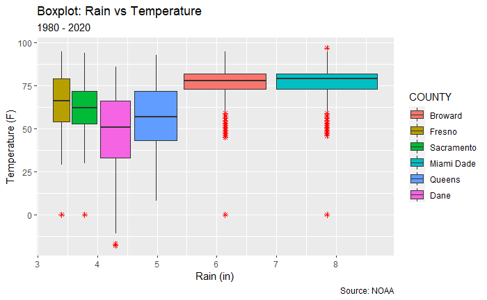

```r
ggplot(data_final, aes(x = RAIN, y= TEMP_AVG, fill = COUNTY)) +
  geom_boxplot(outlier.color = "red", outlier.shape = 8) +
  labs(title = "Boxplot: Rain vs Temperature",
       subtitle = "1980 - 2020",
       x = "Rain (in)",
       y = "Temperature (F)",
       caption = "Source: NOAA")
```

In the boxplot above we are doing our first exploratory analysis graph. We can see that it rains the most in Miami Dade and Broward, and they also have the highest average temperatures. We also see there a couple of bad data points that show 0 Temperature, but in such a huge dataset it will be drowned out. Dane, a county in Wisconsin, has the lowest average temperature while California seems to get the least amount of rain.

# Temperatures during the Summer Months

How hot does it get during summer in our selected counties? From 1980 to 2020, we will see below what average temperatures have been.

```r
question1_mean_temp <-

data_final %>%
  filter(between(month(DATE), 5, 9), !is.na(TEMP_AVG)) %>% #filter for months between may and september, dropping nas
  select(COUNTY, TEMP_AVG) %>%
  group_by(COUNTY) %>%
  summarize(meanT = mean(TEMP_AVG),
            sd_T = sd(TEMP_AVG)) %>%
  arrange(desc(meanT))
question1_mean_temp
```

| COUNTY | meanT | sd_T |
| --- | --- | --- |
| Broward | 81.90529 | 6.036128 |
| Miami Dade | 81.24709 | 4.781478 |
| Sacramento | 72.31415 | 6.770137 |
| Queens | 71.47219 | 8.172312 |
| Fresno | 68.73745 | 11.944167 |
| Dane | 66.52632 | 8.505762 |

Broward county has the highest average temperature with 81.9 degrees F. Miami Dade comes in a close second with 81.2 degrees F. Fresno has a standard deviation of 12 degrees, meaning their data points are very spread out.

### Temp by County

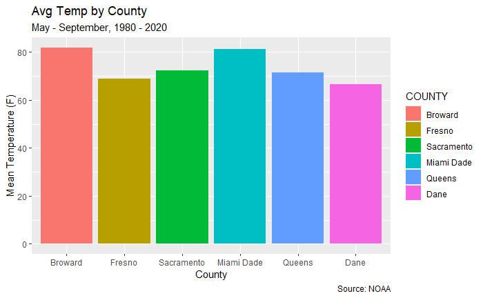

```r
ggplot(question1_mean_temp, aes(x = COUNTY, y = meanT, fill = COUNTY)) +
  geom_col() +
  labs(title = "Avg Temp by County",
       subtitle = "May - September, 1980 - 2020",
       x = "County",
       y = "Mean Temperature (F)",
       caption = "Source: NOAA")
```

Our second plot is a representation of average temperature by county. Visually, Miami Dade and Broward are almost the exact same height. Next we will look at their data to determine if their average temperatures are significant.

# Hypothesis Testing

H<sub>0</sub>: μ<sub>Miami Dade</sub> = μ<sub>Broward</sub>  
H<sub>1</sub>: μ<sub>Miami Dade</sub> ≠ μ<sub>Broward</sub>  
α = 0.05

# Subset Data

```r
q6_md_b <- data_final %>%
           filter(COUNTY == "Miami Dade" | COUNTY == "Broward", !is.na(TEMP_AVG), TEMP_AVG > 0) %>%
           select(COUNTY, TEMP_AVG)
q6_md_b
```

| COUNTY | TEMP_AVG |
| --- | --- |
| Broward | 76 |
| Broward | 74 |
| Broward | 76 |
| Broward | 77 |
| Broward | 70 |
| Broward | 69 |
| Broward | 74 |
| Broward | 74 |
| Broward | 76 |
| Broward | 77 |

[output cut: 990 more lines]

# Tests for Normality

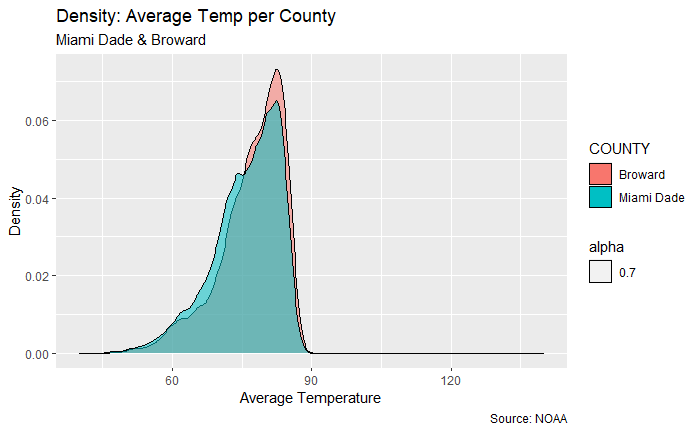

```r
ggplot(q6_md_b, aes(x = TEMP_AVG, fill = COUNTY, alpha = 0.7)) +
  geom_density() +
  labs(title = "Density: Average Temp per County",
       subtitle = "Miami Dade & Broward",
       x = "Average Temperature",
       y = "Density",
       caption = "Source: NOAA"
       )
```

Based on the density plot above, and the sample sizes being over 134,000 points, we can assume data to be normal by the central limit theorem. Therefore, our test would be an unpaired t-test as they are both independent samples.

# T-Test

```r
q6_md <- filter(q6_md_b, COUNTY == "Miami Dade")
q6_b <- filter(q6_md_b, COUNTY == "Broward")
install.packages("forecast")
t.test(q6_md$TEMP_AVG, q6_b$TEMP_AVG, paired = FALSE)
```

```
    Welch Two Sample t-test

data:  q6_md$TEMP_AVG and q6_b$TEMP_AVG
t = -16.046, df = 24418, p-value < 2.2e-16
alternative hypothesis: true difference in means is not equal to 0
95 percent confidence interval:
 -1.350570 -1.056543
sample estimates:
mean of x mean of y
 75.80581  77.00936
```

```r
install.packages("lubridate")
install.packages("corrplot")
```

[output not shown]

```r
install.packages("caret")
```

[output not shown]

p-value of 2.2e-16 is less than our alpha of 0.05, thus reject null hypothesis. There is sufficient evidence to support the claim that the average temperatures between both counties is significant.

# Rain Over the Past Decade

How much rain has fallen, on average, per month from 2010 to 2020?

# Subset the Data

```r
question2_mean_rain <-

data_final %>%
  filter(between(year(DATE), 2010, 2020), !is.na(RAIN), RAIN > 0) %>%
  select(COUNTY, RAIN) %>%
  group_by(COUNTY) %>%
  summarize(meanR = mean(RAIN),
            sd_R = sd(RAIN)) %>%
  arrange(desc(meanR))
question2_mean_rain
```

| COUNTY | meanR | sd_R |
| --- | --- | --- |
| Miami Dade | 0.4600635 | 0.7016729 |
| Broward | 0.4523696 | 0.7252068 |
| Adams | 0.3940887 | 0.6127203 |
| Queens | 0.3693772 | 0.5169356 |
| Dane | 0.3690673 | 0.5436510 |
| Kings | 0.3597771 | 0.4852845 |
| Sacramento | 0.3559341 | 0.4382299 |
| Fresno | 0.3379420 | 0.4465469 |

### Precipitation by County

[figure not shown]

```r
ggplot(question2_mean_rain, aes(x = COUNTY, y = meanR, fill = COUNTY)) +
  geom_col() +
  labs(title = "Avg Precipitation by County",
       subtitle = "2010 - 2020",
       x = "County",
       y = "Rain (in)",
       caption = "Source: NOAA")
```

Visually we see the differences between counties and the amount of average rain per month from 2010 to 2020.

# Rain vs Temperature

Looking specifically at Miami Dade, how much rain has fallen per month of each year when the temperatures have been between 75 and 85 degrees?

# Subset the data

```r
question3_temp <-

data_final %>%
  filter(COUNTY == "Miami Dade", between(TEMP_AVG, 75, 85), !is.na(RAIN), RAIN > 0) %>%
  select(COUNTY, month(data_final$DATE), RAIN) %>%
  group_by(COUNTY, month(DATE)) %>%
  summarize(meanR = mean(RAIN))
question3_temp
```

| COUNTY | month(DATE) | meanR |
| --- | --- | --- |
| Miami Dade | 1 | 0.1892308 |
| Miami Dade | 2 | 0.2646296 |
| Miami Dade | 3 | 0.2678431 |
| Miami Dade | 4 | 0.3860000 |
| Miami Dade | 5 | 0.5411987 |
| Miami Dade | 6 | 0.5087456 |
| Miami Dade | 7 | 0.4642830 |
| Miami Dade | 8 | 0.5052475 |
| Miami Dade | 9 | 0.5285521 |
| Miami Dade | 10 | 0.4827219 |

[output cut: 2 more lines]

# Precipitation by Month

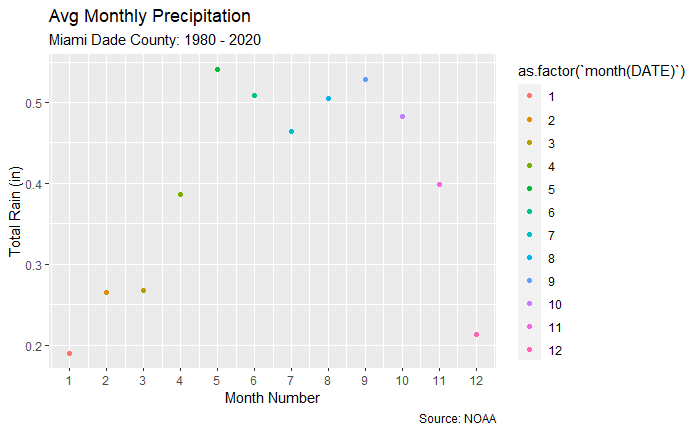

```r
ggplot(question3_temp, aes(x = `month(DATE)`, y = meanR, color = as.factor(`month(DATE)`))) +
  geom_point() +
  labs(title = "Avg Monthly Precipitation",
       subtitle = "Miami Dade County: 1980 - 2020",
       x = "Month Number",
       y = "Total Rain (in)",
       caption = "Source: NOAA") +
  scale_x_continuous(breaks = c(1, 2, 3, 4, 5, 6, 7, 8, 9, 10, 11, 12))
```

# Correlations between Rain and Temperature

For which county does rain and temperature correlate the most (either negative or positive)?

# Subset the Data

```r
q4_rt_broward <-
                      data_final %>%
                      filter(COUNTY == "Broward", !is.na(RAIN), RAIN > 0, !is.na(TEMP_AVG), TEMP_AVG > 0) %>%
                      select(RAIN, TEMP_AVG)

q4_rt_md <-
                      data_final %>%
                      filter(COUNTY == "Miami Dade", !is.na(RAIN), RAIN > 0, !is.na(TEMP_AVG), TEMP_AVG > 0) %>%
                      select(RAIN, TEMP_AVG)
q4_rt_k <-
                      data_final %>%
                      filter(COUNTY == "Kings", !is.na(RAIN), RAIN > 0, !is.na(TEMP_AVG)) %>%
                      select(RAIN, TEMP_AVG)
q4_rt_q <-
                      data_final %>%
                      filter(COUNTY == "Queens", !is.na(RAIN), RAIN > 0, !is.na(TEMP_AVG)) %>%
                      select(RAIN, TEMP_AVG)
q4_rt_f <-
                      data_final %>%
                      filter(COUNTY == "Fresno", !is.na(RAIN), RAIN > 0, !is.na(TEMP_AVG), TEMP_AVG > 0) %>%
                      select(RAIN, TEMP_AVG)
q4_rt_s <-
                      data_final %>%
                      filter(COUNTY == "Sacramento", !is.na(RAIN), RAIN > 0, !is.na(TEMP_AVG), TEMP_AVG > 0) %>%
                      select(RAIN, TEMP_AVG)
q4_rt_d <-
                      data_final %>%
                      filter(COUNTY == "Dane", !is.na(RAIN), RAIN > 0, !is.na(TEMP_AVG)) %>%
                      select(RAIN, TEMP_AVG)
q4_rt_a <-
                      data_final %>%
                      filter(COUNTY == "Adams", !is.na(RAIN), RAIN > 0, !is.na(TEMP_AVG)) %>%
                      select(RAIN, TEMP_AVG)
```

## Broward Correlation

```r
cor(q4_rt_broward)
```

```
                RAIN    TEMP_AVG
RAIN      1.00000000 -0.03539507
TEMP_AVG -0.03539507  1.00000000
```

## Miami Dade Correlation

```r
cor(q4_rt_md)
```

```
               RAIN   TEMP_AVG
RAIN     1.00000000 0.03188158
TEMP_AVG 0.03188158 1.00000000
```

## Kings Correlation

```r
cor(q4_rt_k)
```

```
         RAIN TEMP_AVG
RAIN       NA       NA
TEMP_AVG   NA       NA
```

## Queens Correlation

```r
cor(q4_rt_q)
```

```
               RAIN   TEMP_AVG
RAIN     1.00000000 0.03892235
TEMP_AVG 0.03892235 1.00000000
```

## Fresno Correlation

```r
cor(q4_rt_f)
```

```
               RAIN   TEMP_AVG
RAIN      1.0000000 -0.1199876
TEMP_AVG -0.1199876  1.0000000
```

## Sacramento Correlation

```r
cor(q4_rt_s)
```

```
                RAIN    TEMP_AVG
RAIN      1.00000000 -0.01747611
TEMP_AVG -0.01747611  1.00000000
```

## Dane Correlation

```r
cor(q4_rt_d)
```

```
              RAIN  TEMP_AVG
RAIN     1.0000000 0.2948404
TEMP_AVG 0.2948404 1.0000000
```

## Adams Correlation

```r
cor(q4_rt_a)
```

```
         RAIN TEMP_AVG
RAIN       NA       NA
TEMP_AVG   NA       NA
```

Dane has the highest (though weak) correlation between rain and average temperature. Kings County in New York and Adams County in Wisconsin did not collect temperature data during the time period analyzed.

# Correlation Plot for Dane County

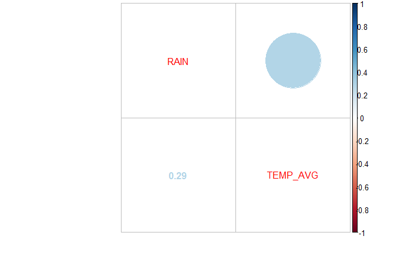

```r
corrplot.mixed(cor(q4_rt_d), lower = "number", upper = "circle")
```

# Sunshine and Average Temperature

Florida is known as “The Sunshine State”. Do their amount of sunshine correlate to the average temperature we experience? How about other states?

```r
q5_st_fl <-
                      data_final %>%
                      filter(STATE == "Florida", !is.na(TEMP_AVG), !is.na(TOTAL_SUNSHINE)) %>%
                      select(TEMP_AVG, TOTAL_SUNSHINE)
q5_st_ny <-
                      data_final %>%
                      filter(STATE == "New York", !is.na(TEMP_AVG), !is.na(TOTAL_SUNSHINE), TOTAL_SUNSHINE > 0) %>%
                      select(TEMP_AVG, TOTAL_SUNSHINE)
q5_st_ca <-
                      data_final %>%
                      filter(STATE == "California", !is.na(TEMP_AVG), !is.na(TOTAL_SUNSHINE)) %>%
                      select(TEMP_AVG, TOTAL_SUNSHINE)
q5_st_wi <-
                      data_final %>%
                      filter(STATE == "Wisconsin", !is.na(TEMP_AVG), !is.na(TOTAL_SUNSHINE)) %>%
                      select(TEMP_AVG, TOTAL_SUNSHINE)
```

# Florida

```r
cor(q5_st_fl)
```

```
                 TEMP_AVG TOTAL_SUNSHINE
TEMP_AVG       1.00000000     0.08865808
TOTAL_SUNSHINE 0.08865808     1.00000000
```

# New York

```r
cor(q5_st_ny)
```

```
               TEMP_AVG TOTAL_SUNSHINE
TEMP_AVG             NA             NA
TOTAL_SUNSHINE       NA             NA
```

# California

```r
cor(q5_st_ca)
```

```
                  TEMP_AVG TOTAL_SUNSHINE
TEMP_AVG        1.00000000    -0.02388489
TOTAL_SUNSHINE -0.02388489     1.00000000
```

# Wisconsin

```r
cor(q5_st_wi)
```

```
the standard deviation is zero
```

```
               TEMP_AVG TOTAL_SUNSHINE
TEMP_AVG              1             NA
TOTAL_SUNSHINE       NA              1
```

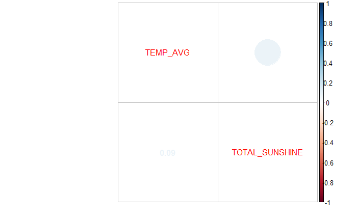

```r
corrplot.mixed(cor(q5_st_fl), lower = "number", upper = "circle")
```

Wisconsin and New York do not collect sunshine data. While no state has any correlation between sunshine and temperature, Florida has the highest with 0.09.

# Loess Regression - Rain vs Temperature

How much rain is predicted to fall in Miami Dade County when the temperature is 80 degrees?

Independent variable: Temperature Dependent variable: Rain

# Subset the Data

```r
q7_md <- data_final %>%
         filter(COUNTY == "Miami Dade", !is.na(TEMP_AVG), !is.na(RAIN), RAIN > 0, TEMP_AVG > 0) %>%
         select(COUNTY, TEMP_AVG, RAIN)
q7_md
```

| COUNTY | TEMP_AVG | RAIN |
| --- | --- | --- |
| Miami Dade | 74 | 0.61 |
| Miami Dade | 77 | 0.01 |
| Miami Dade | 70 | 1.53 |
| Miami Dade | 80 | 0.08 |
| Miami Dade | 80 | 0.03 |
| Miami Dade | 81 | 0.18 |
| Miami Dade | 77 | 0.29 |
| Miami Dade | 78 | 0.08 |
| Miami Dade | 76 | 2.33 |
| Miami Dade | 77 | 1.06 |

[output cut: 990 more lines]

# Linear Correlation

```r
cor.test(q7_md$TEMP_AVG, q7_md$RAIN, method = "pearson")$estimate
```

```
       cor
0.03188158
```

There is no linear correlation between the two variables. Therefore, we will use a loess model.